# 25 - 1-Sample t-Test in R

Methods for computing results for a 1-sample t-test.

### Table of Contents

In the 1-Sample t-test module you learned about the theory underlying a 1-sample t-test and how to perform the calculations required to complete the 11-steps of a hypothesis test. In this module, you will learn how to perform the required calculations from raw data using R. You will also be asked to complete the full 11-steps for a 1-sample t-test.

Methods in this module require the `NCStats` package (as always) and the `ggplot2` package (for making graphs).

```r
library(NCStats)
library(ggplot2)
```

# 1-Sample t-Test in R

If raw data exist, the calculations for a 1-Sample t-test can be efficiently computed with `t.test()`. `t.test()` requires the vector of quantitative data as the first argument, the null hypothesized value for $\mu$ in `mu=`, the type of alternative hypothesis in `alt=` (can be `alt="two.sided"` (the default), `alt="less"`, or `alt="greater"`), and the level of confidence as a proportion in `conf.level=` (defaults to 0.95). If the sample size is less than 40 then you may also need to construct a histogram as described in the Univariate EDA in R module to assess the shape of the distribution.

# Example - Crab Body Temperature

> A marine biologist wants to determine if the body temperature of crabs exposed to ambient air temperature is different than the ambient air temperature. The biologist exposed a sample of 25 crabs to an air temperature of 24.3<sup>o</sup>C for several minutes and then measured the body temperature of each crab (shown below). Test the biologist’s question at the 5% level.

```
22.9,22.9,23.3,23.5,23.9,23.9,24.0,24.3,24.5,24.6,24.6,24.8,24.8,
25.1,25.4,25.4,25.5,25.5,25.8,26.1,26.2,26.3,27.0,27.3,28.1
```

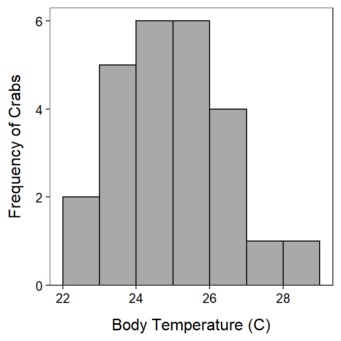

Figure 1: Histogram of the body temperatures of crabs exposed to an ambient temperature of $24.3^{o}$C.

Table 1: Results from 1-Sample t-Test for body temperature of crabs.

| t = 2.7128, df = 24, p-value = 0.01215 |
| --- |
| 95 percent confidence interval: |
| 24.47413 25.58187 |
| sample estimates: |
| mean of x |
| 25.028 |

**R Appendix:**

```r
setwd("c:/data")
df <- read.csv("CrabTemps.csv")
ggplot(data=df,mapping=aes(x=ct)) +
  geom_histogram(boundary=0,binwidth=1,color="black",fill="darkgray") +
  labs(y="Frequency of Crabs",x="Body Temperature (C)") +
  scale_y_continuous(expand=expansion(mult=c(0,0.05))) +
  theme_NCStats()
( ct.t <- t.test(df$ct,mu=24.3,conf.level=0.95) )
```

# Corrections

If you see any errors (code, typographical, or logical) please bring these to my attention.